# Summer Internship

Navin Ramanan

6/01/2022

##Setup

1. Map Ensembl ID to Gene Symbol in the counts file
2. Write Counts Data with Gene Symbol to CSV
3. Reading and filtering Hippocampus count and metadata files
4. Reading and filtering Cortex count and metadata files
5. Cortex: APP=APP, Age=6, Diet=Control vs Supplemented (~APP + Age + Diet) APP6Control vs APP6Supplemented

```
## Cortex: Running DESeq2 for Diet(Control vs Supplemented) with APP=APP, Age=6:padj < 0.05 and 0.10
```

```
## Cortex: APP6Control vs APP6Supplemented
```

```
## resultsNames:
```

```
##  [1] "Intercept"
##  [2] "group_APP12Supplemented_vs_APP12Control"
##  [3] "group_APP3Control_vs_APP12Control"
##  [4] "group_APP3Supplemented_vs_APP12Control"
##  [5] "group_APP6Control_vs_APP12Control"
##  [6] "group_APP6Supplemented_vs_APP12Control"
##  [7] "group_APP9Control_vs_APP12Control"
##  [8] "group_APP9Supplemented_vs_APP12Control"
##  [9] "group_WT12Control_vs_APP12Control"
## [10] "group_WT12Supplemented_vs_APP12Control"
## [11] "group_WT3Control_vs_APP12Control"
## [12] "group_WT3Supplemented_vs_APP12Control"
## [13] "group_WT6Control_vs_APP12Control"
## [14] "group_WT6Supplemented_vs_APP12Control"
## [15] "group_WT9Control_vs_APP12Control"
## [16] "group_WT9Supplemented_vs_APP12Control"
## [1] "group"            "APP6Control"      "APP6Supplemented"
##
## out of 34880 with nonzero total read count
## adjusted p-value < 0.1
## LFC > 0 (up)       : 55, 0.16%
## LFC < 0 (down)     : 1, 0.0029%
## outliers [1]       : 101, 0.29%
## low counts [2]     : 8748, 25%
## (mean count < 1)
## [1] see 'cooksCutoff' argument of ?results
## [2] see 'independentFiltering' argument of ?results
```

```
## log2 fold change (MLE): group APP6Control vs APP6Supplemented
## Wald test p-value: group APP6Control vs APP6Supplemented
## DataFrame with 10 rows and 6 columns
##                     baseMean log2FoldChange     lfcSE      stat      pvalue
##                    <numeric>      <numeric> <numeric> <numeric>   <numeric>
## ENSMUSG00000050366   1.42079       21.96686  2.937449   7.47821 7.53405e-14
## ENSMUSG00000025150 128.49169        3.87547  0.634098   6.11179 9.85195e-10
## ENSMUSG00000004668  27.16596        3.16049  0.527680   5.98941 2.10607e-09
## ENSMUSG00000045394  13.10617        4.55668  0.785658   5.79983 6.63815e-09
## ENSMUSG00000074665  10.23913        4.88056  0.854546   5.71130 1.12119e-08
## ENSMUSG00000056973  25.74054        5.96903  1.058609   5.63856 1.71474e-08
## ENSMUSG00000036292  69.40188        2.03746  0.362857   5.61507 1.96488e-08
## ENSMUSG00000049353  17.02618        4.82028  0.880807   5.47258 4.43538e-08
## ENSMUSG00000031789  20.32289        3.97122  0.729810   5.44145 5.28479e-08
## ENSMUSG00000051663   9.01741        4.72836  0.872017   5.42233 5.88269e-08
##                           padj
##                      <numeric>
## ENSMUSG00000050366 1.96119e-09
## ENSMUSG00000025150 1.28228e-05
## ENSMUSG00000004668 1.82744e-05
## ENSMUSG00000045394 4.31994e-05
## ENSMUSG00000074665 5.83712e-05
## ENSMUSG00000056973 7.30683e-05
## ENSMUSG00000036292 7.30683e-05
## ENSMUSG00000049353 1.44322e-04
## ENSMUSG00000031789 1.52854e-04
## ENSMUSG00000051663 1.53132e-04
```

```
## log2 fold change (MLE): group APP6Control vs APP6Supplemented
## Wald test p-value: group APP6Control vs APP6Supplemented
## DataFrame with 34880 rows and 6 columns
##                     baseMean log2FoldChange     lfcSE      stat      pvalue
##                    <numeric>      <numeric> <numeric> <numeric>   <numeric>
## ENSMUSG00000050366   1.42079       21.96686  2.937449   7.47821 7.53405e-14
## ENSMUSG00000025150 128.49169        3.87547  0.634098   6.11179 9.85195e-10
## ENSMUSG00000004668  27.16596        3.16049  0.527680   5.98941 2.10607e-09
## ENSMUSG00000045394  13.10617        4.55668  0.785658   5.79983 6.63815e-09
## ENSMUSG00000074665  10.23913        4.88056  0.854546   5.71130 1.12119e-08
## ...                      ...            ...       ...       ...         ...
## ENSMUSG00000064359  0.161461       0.326981   8.24541 0.0396562    0.968367
## ENSMUSG00000064366  0.117536       0.326981   8.24541 0.0396562    0.968367
## ENSMUSG00000095672  0.103382       0.326981   8.24541 0.0396562    0.968367
## ENSMUSG00000079222  0.124061       0.000000   8.24541 0.0000000    1.000000
## ENSMUSG00000079794  0.341101       0.000000   4.45429 0.0000000    1.000000
##                           padj
##                      <numeric>
## ENSMUSG00000050366 1.96119e-09
## ENSMUSG00000025150 1.28228e-05
## ENSMUSG00000004668 1.82744e-05
## ENSMUSG00000045394 4.31994e-05
## ENSMUSG00000074665 5.83712e-05
## ...                        ...
## ENSMUSG00000064359          NA
## ENSMUSG00000064366          NA
## ENSMUSG00000095672          NA
## ENSMUSG00000079222          NA
## ENSMUSG00000079794          NA
```

```
## class: DESeqDataSet
## dim: 34880 96
## metadata(1): version
## assays(4): counts mu H cooks
## rownames(34880): ENSMUSG00000102628 ENSMUSG00000097426 ...
##   ENSMUSG00000095041 ENSMUSG00000095742
## rowData names(78): baseMean baseVar ... deviance maxCooks
## colnames(96): 102 103 ... 95 96
## colData names(6): Sex Diet ... group sizeFactor
```

```
## Cortex DESeq2 result is saved in file: 'Cortex_deseq_results_Diet_APP_6.csv'
```

```
## Cortex DESeq2 normalized counts is saved in file: 'Cortex_deseq_norm_counts_Diet_APP_6.csv'
```

```
## Cortex DESeq2 result with Gene names (mgi_symbols) is saved in file: 'Cortex_deseq_results_with_genename_Diet_APP_6.csv'
```

```
## [1] 34880
```

```
## [1] 39
```

```
## Cortex DESeq2 result after padj (0.05) filtering is saved in file: 'Cortex_deseq_results_Diet_APP_6_padj_05_filtered.csv'
```

```
## Number of DE genes significant at padj < 0.05 for Cortex:APP6Control vs APP6Supplemented: 39
```

```
## Number of DE genes discarded after padj threshold 0.05 filtering for Cortex:APP6Control vs APP6Supplemented: 34841
```

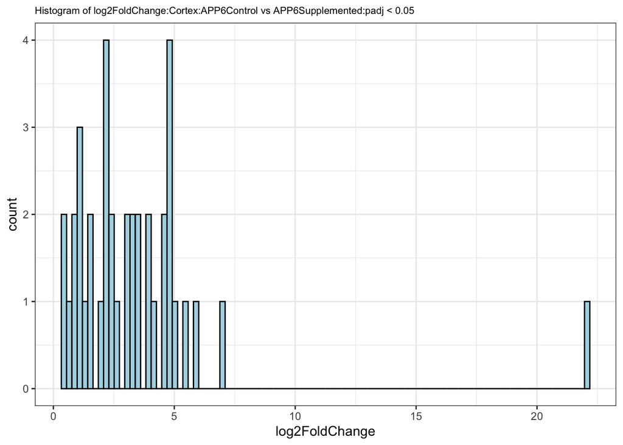

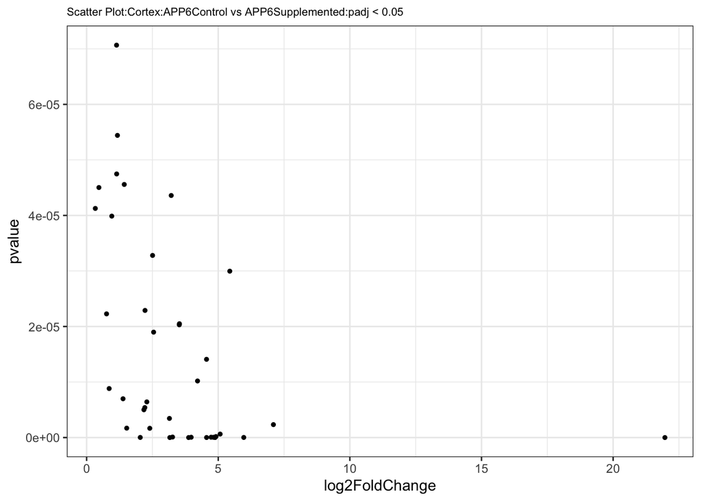

```
## [1] 34880
```

```
## [1] 56
```

```
## Cortex DESeq2 result after padj (0.1) filtering is saved in file: 'Cortex_deseq_results_Diet_APP_6_padj_1_filtered.csv'
```

```
## Number of DE genes significant at padj < 0.1 for Cortex:APP6Control vs APP6Supplemented: 56
```

```
## Number of DE genes discarded after padj threshold 0.1 filtering for Cortex:APP6Control vs APP6Supplemented: 34824
```

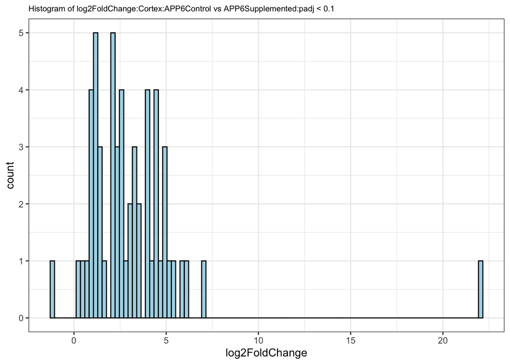

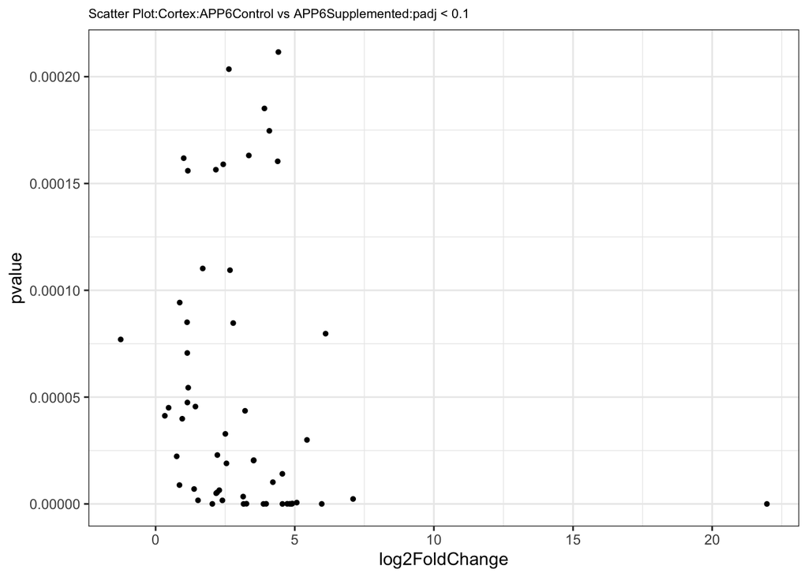

6. Cortex: Enhanced Volcano Plot

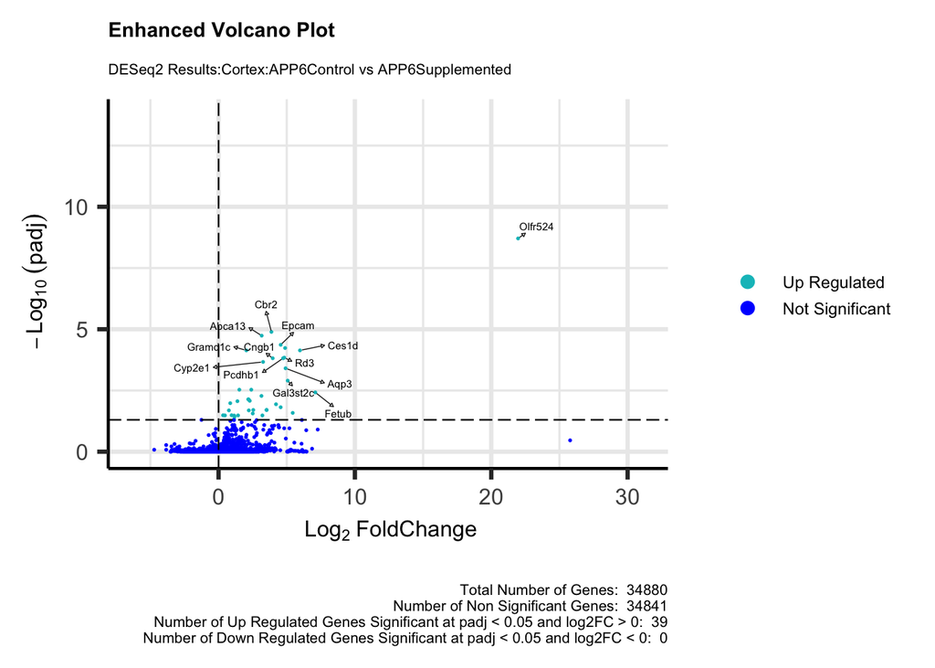

7. Cortex: Heatmap

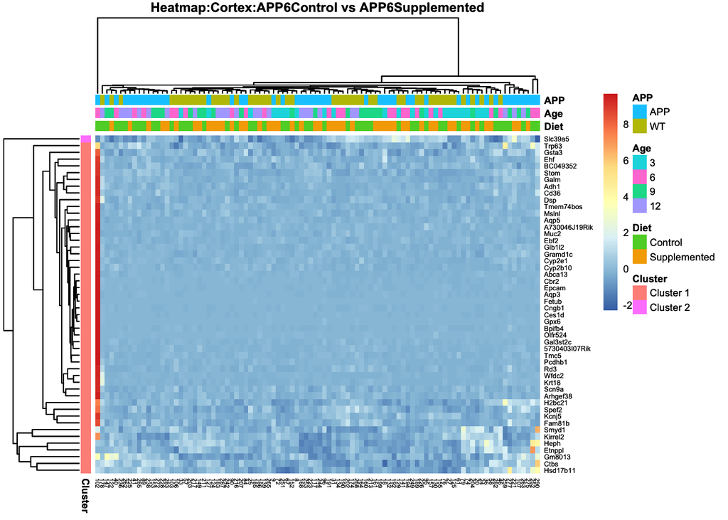

8. Hippocampus: APP=APP, Age=6, Diet=Control vs Supplemented (~APP + Age + Diet) APP6Control vs APP6Supplemented

```
## Hippocampus: Running DESeq2 for Diet(Control vs Supplemented) with APP=APP, Age=6:padj < 0.05 and 0.10
```

```
## Hippocampus: APP6Control vs APP6Supplemented
```

```
## resultsNames:
```

```
##  [1] "Intercept"
##  [2] "group_APP12Supplemented_vs_APP12Control"
##  [3] "group_APP3Control_vs_APP12Control"
##  [4] "group_APP3Supplemented_vs_APP12Control"
##  [5] "group_APP6Control_vs_APP12Control"
##  [6] "group_APP6Supplemented_vs_APP12Control"
##  [7] "group_APP9Control_vs_APP12Control"
##  [8] "group_APP9Supplemented_vs_APP12Control"
##  [9] "group_WT12Control_vs_APP12Control"
## [10] "group_WT12Supplemented_vs_APP12Control"
## [11] "group_WT3Control_vs_APP12Control"
## [12] "group_WT3Supplemented_vs_APP12Control"
## [13] "group_WT6Control_vs_APP12Control"
## [14] "group_WT6Supplemented_vs_APP12Control"
## [15] "group_WT9Control_vs_APP12Control"
## [16] "group_WT9Supplemented_vs_APP12Control"
## [1] "group"            "APP6Control"      "APP6Supplemented"
##
## out of 33271 with nonzero total read count
## adjusted p-value < 0.1
## LFC > 0 (up)       : 1, 0.003%
## LFC < 0 (down)     : 0, 0%
## outliers [1]       : 77, 0.23%
## low counts [2]     : 0, 0%
## (mean count < 0)
## [1] see 'cooksCutoff' argument of ?results
## [2] see 'independentFiltering' argument of ?results
```

```
## log2 fold change (MLE): group APP6Control vs APP6Supplemented
## Wald test p-value: group APP6Control vs APP6Supplemented
## DataFrame with 10 rows and 6 columns
##                      baseMean log2FoldChange     lfcSE      stat      pvalue
##                     <numeric>      <numeric> <numeric> <numeric>   <numeric>
## ENSMUSG00000066720    5.43956      18.566496  2.830417   6.55963 5.39400e-11
## ENSMUSG00000091243  127.72278      -2.526812  0.559843  -4.51343 6.37886e-06
## ENSMUSG00000067149   23.26136      -2.313960  0.561087  -4.12407 3.72237e-05
## ENSMUSG00000040605   87.42120      -1.481393  0.365135  -4.05711 4.96841e-05
## ENSMUSG00000033021  581.47198       0.886944  0.358560   2.47363 1.33750e-02
## ENSMUSG00000033007   47.66471       1.523608  0.536046   2.84231 4.47883e-03
## ENSMUSG00000018417  745.16453      -0.390030  0.155580  -2.50694 1.21783e-02
## ENSMUSG00000026489 1397.39330       0.599123  0.261552   2.29065 2.19838e-02
## ENSMUSG00000055676  135.18753       0.754050  0.282967   2.66480 7.70336e-03
## ENSMUSG00000048402  137.22606       0.733023  0.244835   2.99394 2.75396e-03
##                           padj
##                      <numeric>
## ENSMUSG00000066720 1.79048e-06
## ENSMUSG00000091243 1.05870e-01
## ENSMUSG00000067149 4.11868e-01
## ENSMUSG00000040605 4.12303e-01
## ENSMUSG00000033021 4.97042e-01
## ENSMUSG00000033007 4.97042e-01
## ENSMUSG00000018417 4.97042e-01
## ENSMUSG00000026489 4.97042e-01
## ENSMUSG00000055676 4.97042e-01
## ENSMUSG00000048402 4.97042e-01
```

```
## log2 fold change (MLE): group APP6Control vs APP6Supplemented
## Wald test p-value: group APP6Control vs APP6Supplemented
## DataFrame with 33271 rows and 6 columns
##                       baseMean log2FoldChange     lfcSE      stat      pvalue
##                      <numeric>      <numeric> <numeric> <numeric>   <numeric>
## ENSMUSG00000066720     5.43956      18.566496  2.830417   6.55963 5.39400e-11
## ENSMUSG00000091243   127.72278      -2.526812  0.559843  -4.51343 6.37886e-06
## ENSMUSG00000067149    23.26136      -2.313960  0.561087  -4.12407 3.72237e-05
## ENSMUSG00000040605    87.42120      -1.481393  0.365135  -4.05711 4.96841e-05
## ENSMUSG00000033021   581.47198       0.886944  0.358560   2.47363 1.33750e-02
## ...                        ...            ...       ...       ...         ...
## ENSMUSG00000068196   434.29152      -1.278361   1.20101 -1.064408          NA
## ENSMUSG00000053375     1.58633      -0.776070   3.32032 -0.233734          NA
## ENSMUSG00000023122    38.89638      -0.473593   2.54961 -0.185751          NA
## ENSMUSG00000023943    18.46229      -1.609907   2.77503 -0.580141          NA
## ENSMUSG00000061808 34756.71162      -1.165837   1.53502 -0.759494          NA
##                           padj
##                      <numeric>
## ENSMUSG00000066720 1.79048e-06
## ENSMUSG00000091243 1.05870e-01
## ENSMUSG00000067149 4.11868e-01
## ENSMUSG00000040605 4.12303e-01
## ENSMUSG00000033021 4.97042e-01
## ...                        ...
## ENSMUSG00000068196          NA
## ENSMUSG00000053375          NA
## ENSMUSG00000023122          NA
## ENSMUSG00000023943          NA
## ENSMUSG00000061808          NA
```

```
## class: DESeqDataSet
## dim: 33271 96
## metadata(1): version
## assays(4): counts mu H cooks
## rownames(33271): ENSMUSG00000102628 ENSMUSG00000086053 ...
##   ENSMUSG00000095041 ENSMUSG00000095742
## rowData names(78): baseMean baseVar ... deviance maxCooks
## colnames(96): 102 103 ... 95 96
## colData names(6): Sex Diet ... group sizeFactor
```

```
## Hippocampus DESeq2 result is saved in file: 'Hippocampus_deseq_results_Diet_APP_6.csv'
```

```
## Hippocampus DESeq2 normalized counts is saved in file: 'Hippocampus_deseq_norm_counts_Diet_APP_6.csv'
```

```
## Hippocampus DESeq2 result with Gene names (mgi_symbols) is saved in file: 'Hippocampus_deseq_results_with_genename_Diet_APP_6.csv'
```

```
## Hippocampus DESeq2 result after padj (0.05) filtering is saved in file: 'Hippocampus_deseq_results_Diet_APP_6_padj_05_filtered.csv'
```

```
## Number of DE genes significant at padj < 0.05 for Hippocampus:APP6Control vs APP6Supplemented: 1
```

```
## Number of DE genes discarded after padj threshold < 0.05 filtering for Hippocampus:APP6Control vs APP6Supplemented: 33270
```

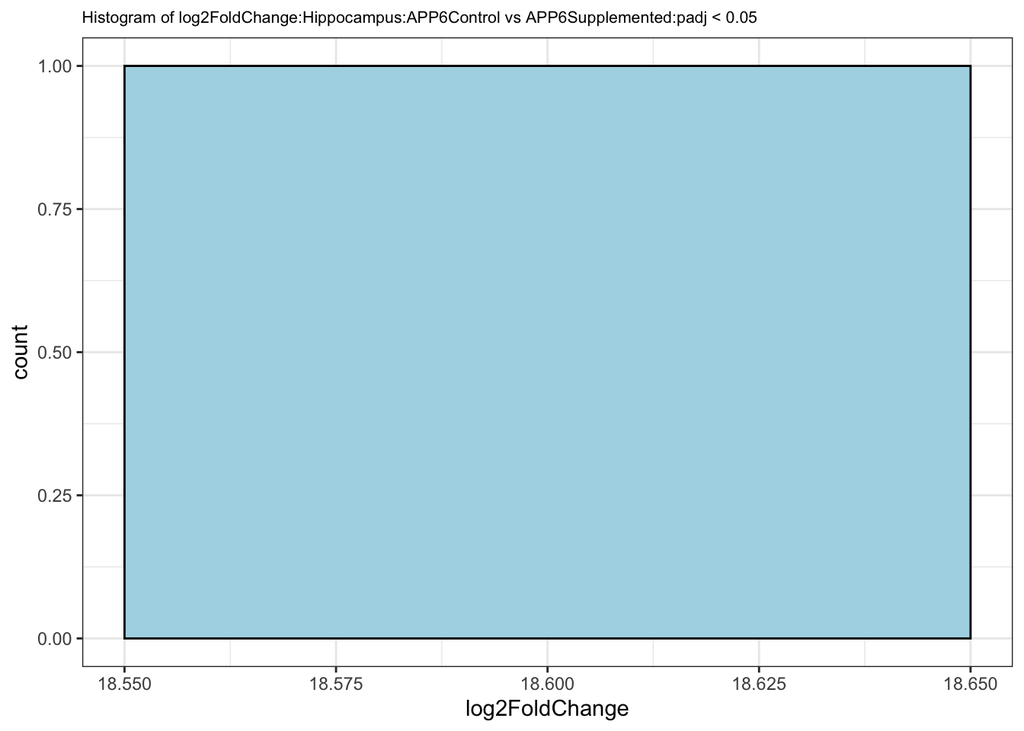

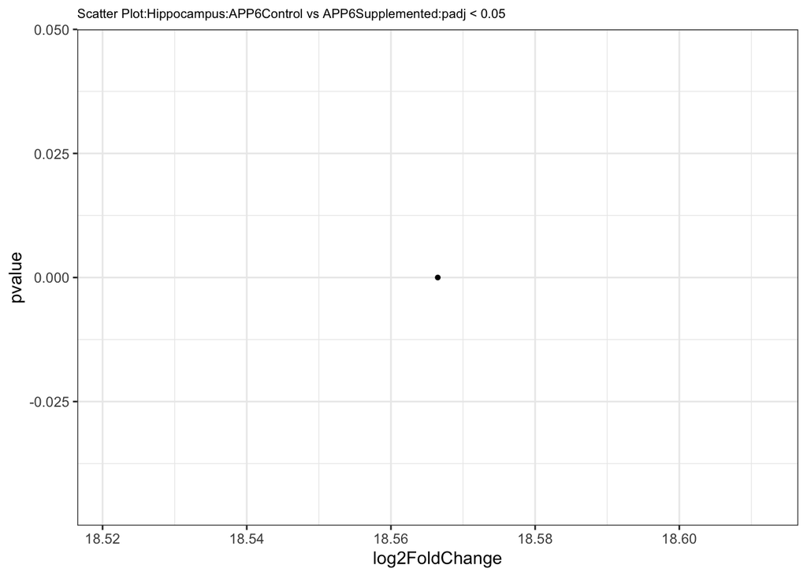

```
## Hippocampus DESeq2 result after padj (0.1) filtering is saved in file: 'Hippocampus_deseq_results_Diet_APP_6_padj_1_filtered.csv'
```

```
## Number of DE genes significant at padj < 0.1 for Hippocampus:APP6Control vs APP6Supplemented: 1
```

```
## Number of DE genes discarded after padj threshold < 0.1 filtering for Hippocampus:APP6Control vs APP6Supplemented: 33270
```

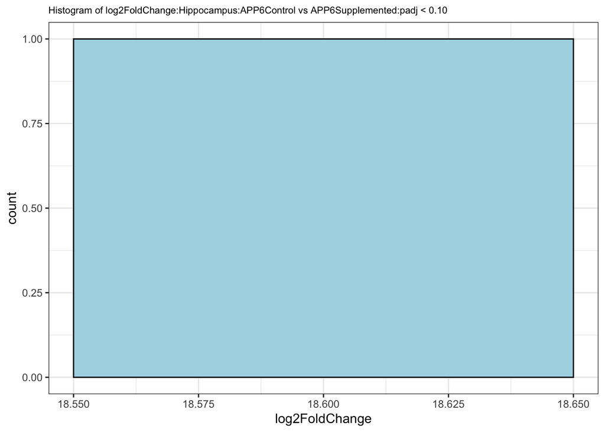

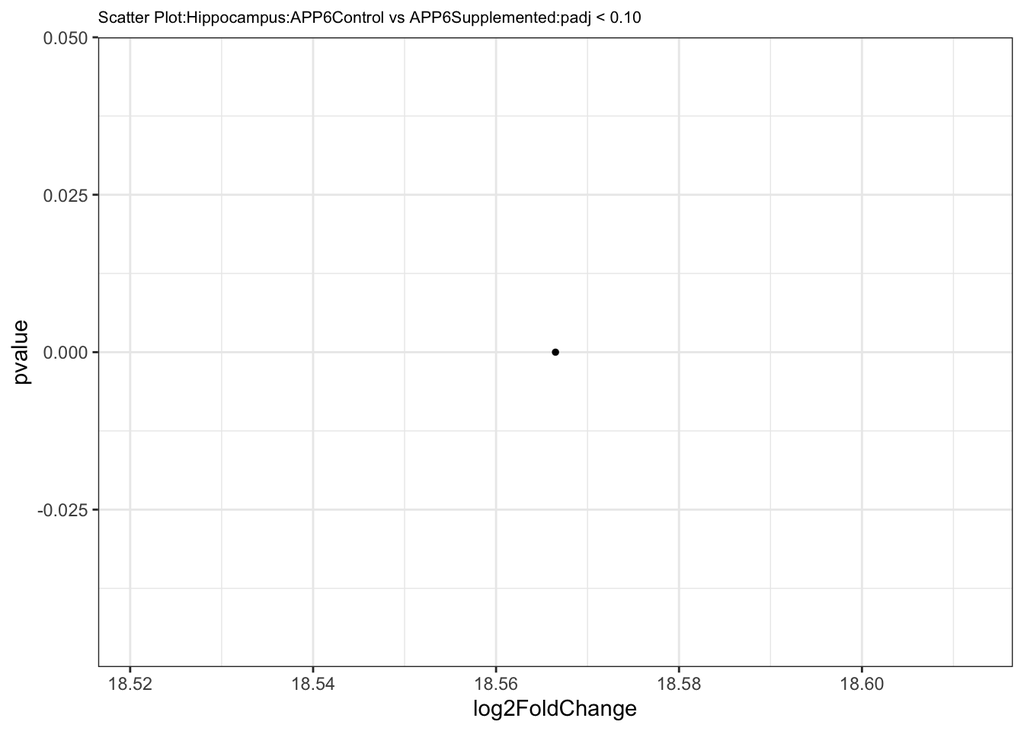

9. Hippocampus: Enhanced Volcano Plot

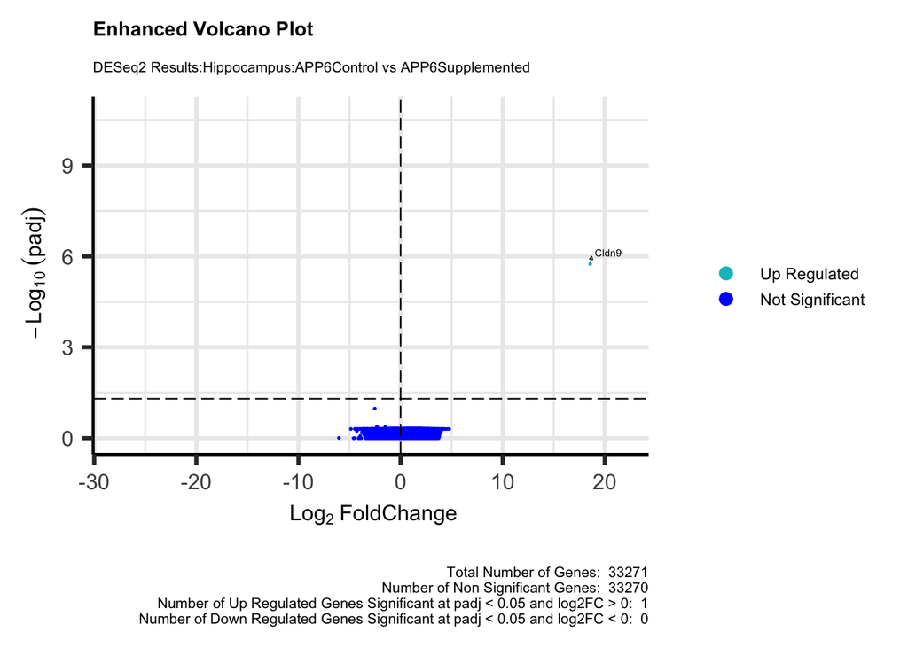

10. Hippocampus: Heatmap

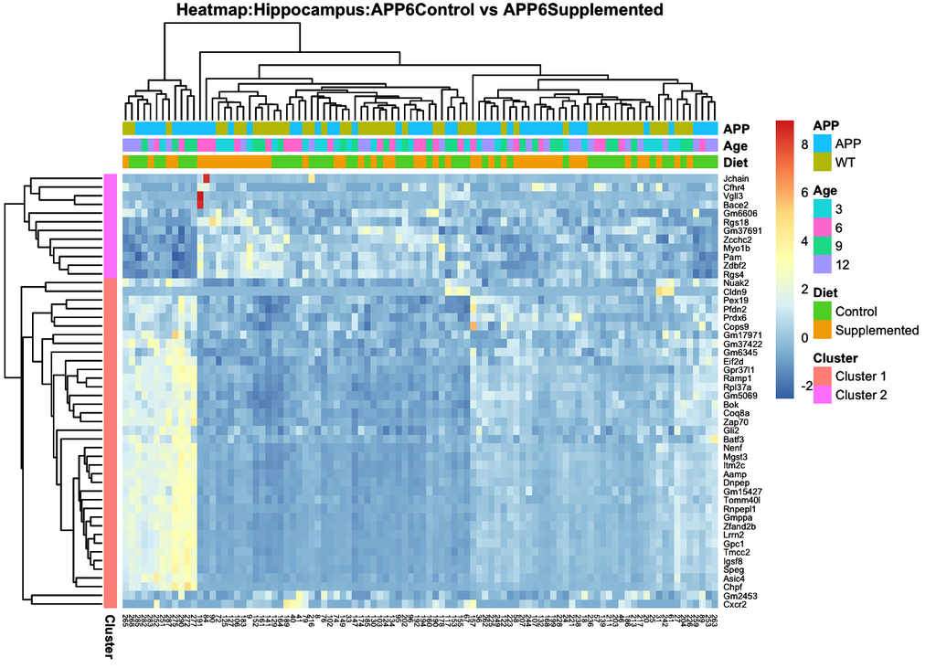

11. GSEA:Running fgsea

Perform a GSEA using a ranked list log2FoldChange values for all genes discovered in the DESeq2 results against the M2 Canonical Pathways gene set collection. Convert gene identifiers in the results to the appropriate matching format found in the M2 gene sets. fgsea expects a named vector of gene level statistics and the gene sets in the form of a named list.

Using “m2.cp.wikipathways.v0.3.symbols.gmt” which is the Canonical Pathways gene sets derived from the WikiPathways pathway database (WikiPathways subset of CP)

```
## # A tibble: 34,880 × 8
##    genes              volc_plot_s…¹ log2F…²    padj baseM…³ lfcSE  stat   pvalue
##    <chr>              <chr>           <dbl>   <dbl>   <dbl> <dbl> <dbl>    <dbl>
##  1 ENSMUSG00000050366 UP              22.0  1.96e-9    1.42 2.94   7.48 7.53e-14
##  2 ENSMUSG00000025150 UP               3.88 1.28e-5  128.   0.634  6.11 9.85e-10
##  3 ENSMUSG00000004668 UP               3.16 1.83e-5   27.2  0.528  5.99 2.11e- 9
##  4 ENSMUSG00000045394 UP               4.56 4.32e-5   13.1  0.786  5.80 6.64e- 9
##  5 ENSMUSG00000074665 UP               4.88 5.84e-5   10.2  0.855  5.71 1.12e- 8
##  6 ENSMUSG00000056973 UP               5.97 7.31e-5   25.7  1.06   5.64 1.71e- 8
##  7 ENSMUSG00000036292 UP               2.04 7.31e-5   69.4  0.363  5.62 1.96e- 8
##  8 ENSMUSG00000049353 UP               4.82 1.44e-4   17.0  0.881  5.47 4.44e- 8
##  9 ENSMUSG00000031789 UP               3.97 1.53e-4   20.3  0.730  5.44 5.28e- 8
## 10 ENSMUSG00000051663 UP               4.73 1.53e-4    9.02 0.872  5.42 5.88e- 8
## # … with 34,870 more rows, and abbreviated variable names ¹volc_plot_status,
## #   ²log2FoldChange, ³baseMean
## # ℹ Use `print(n = ...)` to see more rows
```

```
## # A tibble: 190 × 8
##    pathway                        pval  padj log2err     ES    NES  size leadi…¹
##    <chr>                         <dbl> <dbl>   <dbl>  <dbl>  <dbl> <int> <list>
##  1 WP_GLUTATHIONE_METABOLISM    0.0178 0.260  0.352  -0.666 -1.59     20 <chr>
##  2 WP_CHOLESTEROL_BIOSYNTHESIS  0.0812 0.877  0.271  -0.626 -1.40     15 <chr>
##  3 WP_MIRNAS_AND_TFS_IN_IPS_CE… 0.192  1      0.161  -0.705 -1.27      7 <chr>
##  4 WP_GPCRS_ORPHAN              0.178  1      0.185  -0.520 -1.22     19 <chr>
##  5 WP_PEROXIREDOXIN_2_INDUCED_… 0.297  1      0.120  -0.674 -1.18      6 <chr>
##  6 WP_HYPOTHETICAL_NETWORK_FOR… 0.191  1      0.185  -0.439 -1.16     31 <chr>
##  7 WP_ROBO4_AND_VEGF_SIGNALING… 0.387  1      0.103  -0.633 -1.11      6 <chr>
##  8 WP_DYSREGULATED_MIRNA_TARGE… 0.413  1      0.120  -0.413 -1.04     26 <chr>
##  9 WP_IRON_HOMEOSTASIS          0.398  1      0.112  -0.463 -1.03     14 <chr>
## 10 WP_HFE_EFFECT_ON_HEPCIDIN_P… 0.494  1      0.0934 -0.551 -0.994     7 <chr>
## # … with 180 more rows, and abbreviated variable name ¹leadingEdge
## # ℹ Use `print(n = ...)` to see more rows
```

```
## Cortex NES ordered fgsea results saved in file: 'Cortex_NES_ordered_fgsea_results_Diet_APP_6_FC0.csv'
```

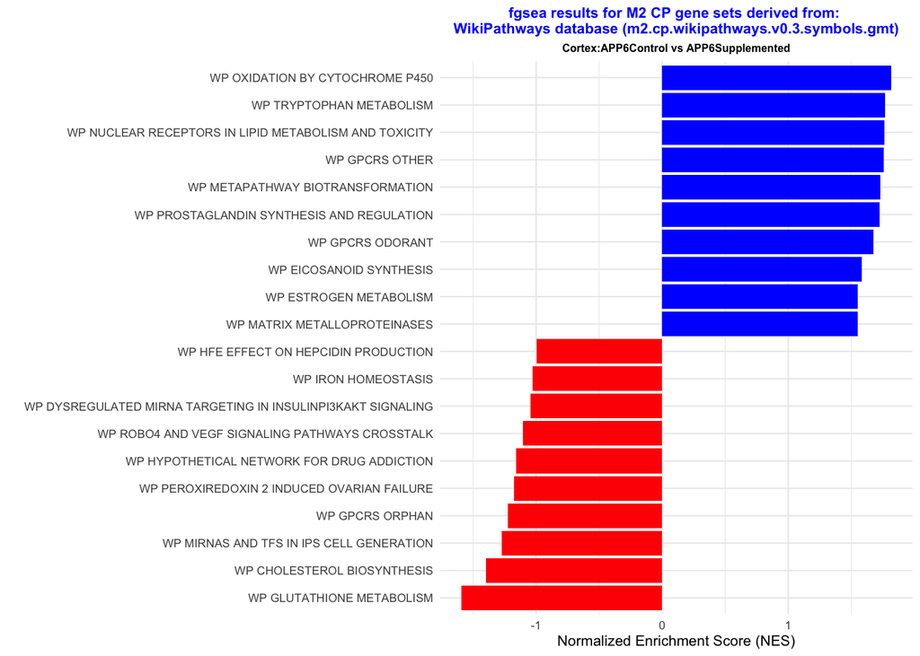

```
## # A tibble: 33,271 × 8
##    genes              volc_plot_s…¹ log2F…²    padj baseM…³ lfcSE  stat   pvalue
##    <chr>              <chr>           <dbl>   <dbl>   <dbl> <dbl> <dbl>    <dbl>
##  1 ENSMUSG00000066720 UP             18.6   1.79e-6    5.44 2.83   6.56 5.39e-11
##  2 ENSMUSG00000091243 NS             -2.53  1.06e-1  128.   0.560 -4.51 6.38e- 6
##  3 ENSMUSG00000067149 NS             -2.31  4.12e-1   23.3  0.561 -4.12 3.72e- 5
##  4 ENSMUSG00000040605 NS             -1.48  4.12e-1   87.4  0.365 -4.06 4.97e- 5
##  5 ENSMUSG00000033021 NS              0.887 4.97e-1  581.   0.359  2.47 1.34e- 2
##  6 ENSMUSG00000033007 NS              1.52  4.97e-1   47.7  0.536  2.84 4.48e- 3
##  7 ENSMUSG00000018417 NS             -0.390 4.97e-1  745.   0.156 -2.51 1.22e- 2
##  8 ENSMUSG00000026489 NS              0.599 4.97e-1 1397.   0.262  2.29 2.20e- 2
##  9 ENSMUSG00000055676 NS              0.754 4.97e-1  135.   0.283  2.66 7.70e- 3
## 10 ENSMUSG00000048402 NS              0.733 4.97e-1  137.   0.245  2.99 2.75e- 3
## # … with 33,261 more rows, and abbreviated variable names ¹volc_plot_status,
## #   ²log2FoldChange, ³baseMean
## # ℹ Use `print(n = ...)` to see more rows
```

```
## # A tibble: 190 × 8
##    pathway                         pval  padj log2err     ES   NES  size leadi…¹
##    <chr>                          <dbl> <dbl>   <dbl>  <dbl> <dbl> <int> <list>
##  1 WP_GLUCURONIDATION            0.0474 0.600   0.322 -0.730 -1.53     9 <chr>
##  2 WP_PROSTAGLANDIN_SYNTHESIS_A… 0.0298 0.600   0.352 -0.522 -1.48    30 <chr>
##  3 WP_ESTROGEN_METABOLISM        0.0711 0.666   0.262 -0.691 -1.45     9 <chr>
##  4 WP_TRANSCRIPTIONAL_ACTIVATIO… 0.126  0.760   0.194 -0.571 -1.34    14 <chr>
##  5 WP_STEROID_BIOSYNTHESIS       0.237  0.819   0.137 -0.569 -1.19     9 <chr>
##  6 WP_GPCRS_PEPTIDE              0.186  0.819   0.160 -0.356 -1.19    69 <chr>
##  7 WP_OXIDATIVE_STRESS_AND_REDO… 0.236  0.819   0.141 -0.324 -1.11    91 <chr>
##  8 WP_GLUTATHIONE_METABOLISM     0.319  0.879   0.116 -0.426 -1.11    20 <chr>
##  9 WP_GPCRS_CLASS_A_RHODOPSINLI… 0.278  0.849   0.136 -0.287 -1.07   164 <chr>
## 10 WP_GPCRS_NONODORANT           0.259  0.842   0.152 -0.273 -1.07   250 <chr>
## # … with 180 more rows, and abbreviated variable name ¹leadingEdge
## # ℹ Use `print(n = ...)` to see more rows
```

```
## Hippocampus NES ordered fgsea results saved in file: 'Hippocampus_NES_ordered_fgsea_results_Diet_APP_6_FC0.csv'
```

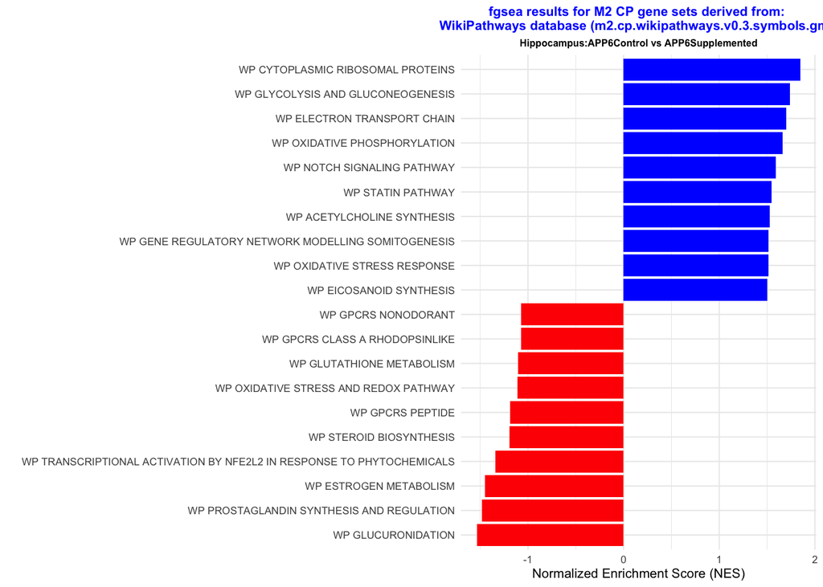